# Log-Time Quantum Gravity (LTQG)

## *A Comprehensive Educational Journey Through Temporal Unification*

**Author:** Denzil James Greenwood  
**Version:** 2.0 – October 2025  
**Repository:** github.com/DenzilGreenwood/log_time

### 📚 Educational Companion to Research Papers

This notebook serves as an interactive educational companion to:

1. **Greenwood, D.J. (2025a).** *"Log-Time Quantum Gravity: A Reparameterization Approach to Temporal Unification in General Relativity and Quantum Mechanics"* [[PDF](https://denzilgreenwood.github.io/log_time/LTQG_Research_Paper.pdf)]
2. **Greenwood, D.J. (2025b).** *"Log-Time Quantum Gravity and the Problem of Time in Canonical Quantum Gravity"* [[PDF](https://denzilgreenwood.github.io/log_time/LTQG_Problem_of_Time.pdf)]

### 🎯 Learning Objectives

By the end of this notebook, you will understand:

- How the **σ = log(τ/τ₀)** transformation unifies General Relativity and Quantum Mechanics
- The mathematical implementation of LTQG in Python
- **Asymptotic silence** and singularity regularization mechanisms
- Experimental predictions and distinguishability analysis
- Integration with major quantum gravity approaches
- Real-world applications from quantum experiments to cosmology

### 🚀 Interactive Features

- **Complete Python implementation** of LTQG mathematics
- **Publication-quality visualizations** of all key concepts
- **Hands-on exercises** with modifiable parameters
- **Experimental simulations** with realistic sensitivity analysis
- **Cross-references** to research papers throughout

### 📖 Table of Contents

[output not shown]

**🔧 Requirements:** Python 3.8+, NumPy, SciPy, Matplotlib, (optional: NetworkX for visualizations)

**▶️ Ready to explore? Let's begin the journey into Log-Time Quantum Gravity!**

# 1. Introduction: The Temporal Incompatibility Crisis

Welcome to the fascinating world of **Log-Time Quantum Gravity (LTQG)**! This notebook will take you on an interactive journey through one of the most elegant solutions to the century-old problem of unifying General Relativity and Quantum Mechanics.

## 1.1 The Fundamental Problem

The incompatibility between General Relativity (GR) and Quantum Mechanics (QM) runs deeper than most people realize. It's not just about "making gravity quantum"—it's about a fundamental mismatch in how the theories treat **time itself**.

### General Relativity: Multiplicative Time

In Einstein's theory, time dilation follows a **multiplicative** structure:

```
τ' = γ(v, Φ) × τ
```

Where gravitational and kinematic effects multiply the time interval.

### Quantum Mechanics: Additive Time

In quantum theory, phase evolution follows an **additive** structure:

```
φ = E₁t₁ + E₂t₂ + E₃t₃ + ...
```

Where quantum phases accumulate linearly with time.

### The Core Issue

**How can you unify theories that fundamentally disagree about whether time effects add or multiply?**

This is where LTQG provides an elegant solution through the logarithmic transformation:

$$\boxed{\sigma = \log\left(\frac{\tau}{\tau_0}\right)}$$

Since **log(ab) = log(a) + log(b)**, this transformation converts multiplication into addition!

> 🔍 **Why it matters:** The σ = log(τ/τ₀) transformation linearizes time-dilation effects, allowing quantum evolution to remain unitary in gravitational fields while preserving all the physics of General Relativity.

## 1.2 What Makes LTQG Special?

LTQG is **not** another attempt to "quantize gravity" or "make spacetime discrete." Instead, it's a precise mathematical solution to the temporal incompatibility problem that:

### ✨ Key Features:

- **Preserves both theories**: No modification to GR or QM equations
- **Natural regularization**: Singularities become "asymptotically silent"
- **Experimentally testable**: Predicts measurable differences in precision experiments
- **Mathematically elegant**: Uses only logarithms—no exotic physics required
- **Computationally tractable**: Enables numerical solutions to previously intractable problems

### 🎯 Learning Path:

This notebook will guide you through:

1. **Mathematical foundations** with interactive Python implementations
2. **Physical insights** through visualization and analysis
3. **Real applications** from quantum experiments to cosmology
4. **Research connections** to major quantum gravity programs

Let's start by setting up our computational environment!

## 1.3 The Fundamental Problem

### 🤔 The Time Conflict

General Relativity and Quantum Mechanics use fundamentally incompatible concepts of time:

| Aspect | General Relativity | Quantum Mechanics |
| --- | --- | --- |
| **Time Nature** | Dynamic, curved spacetime | Fixed background parameter |
| **Simultaneity** | Relative, observer-dependent | Absolute, global |
| **Evolution** | Geometric (geodesics) | Unitary operators U(t) |
| **Measurement** | Continuous, deterministic | Probabilistic, discrete |

### 💡 Why It Matters

When physicists try to combine these theories:

- QM's time parameter `t` becomes meaningless in curved spacetime
- GR's dynamic time conflicts with QM's fixed evolution parameter
- Standard quantization procedures break down near singularities
- No experimental predictions emerge from most quantum gravity theories

### 🎯 LTQG's Solution Preview

Instead of modifying either theory, LTQG introduces a **logarithmic time transformation**:

$$\sigma = \log\left(\frac{\tau}{\tau_0}\right)$$

where:

- `τ` is proper time (GR)
- `σ` is the "log-time" parameter (natural for QM)
- `τ₀` is a reference time scale

This simple change allows both theories to operate in their natural domains while maintaining mathematical consistency.

### 🔬 What Makes This Testable?

Unlike other quantum gravity approaches, LTQG makes specific predictions:

- Precision atomic clock experiments
- Gravitational wave interferometry
- Quantum measurement protocols
- Cosmological observations

Let's see how this works mathematically!

## 1.4 Mathematical Preview

### 📐 The Core Transformation

The heart of LTQG is deceptively simple:

$$\boxed{\sigma = \log\left(\frac{\tau}{\tau_0}\right) \quad \Leftrightarrow \quad \tau = \tau_0 e^{\sigma}}$$

### 🔄 Why Logarithms?

1. **Scale Independence**: Maps $(0, \infty) \rightarrow (-\infty, \infty)$
2. **Natural for QM**: Symmetric evolution in both directions
3. **Singularity Regularization**: $\tau \rightarrow 0$ becomes $\sigma \rightarrow -\infty$
4. **Computational Advantage**: Exponential growth → Linear growth

### ⚖️ Derivative Relations

From the transformation, we get:

$$\frac{d\sigma}{d\tau} = \frac{1}{\tau}, \quad \frac{d\tau}{d\sigma} = \tau = \tau_0 e^{\sigma}$$

This means:

- Early times (small τ): Large dσ/dτ → Enhanced quantum effects
- Late times (large τ): Small dσ/dτ → Classical limit recovery

### 🌟 Key Insight

**LTQG doesn't change physics—it changes the mathematical language used to describe the same physics.**

Think of it like switching from Celsius to Kelvin temperature scales:

- The physical temperature doesn't change
- But mathematical relationships become simpler
- And some calculations become possible that weren't before

### 🎯 Learning Objectives for This Section:

After working through the mathematics, you'll understand:

- How the σ-τ transformation preserves physical content
- Why this resolves the time conflict between GR and QM
- How to convert between coordinate systems
- Where experimental predictions come from

Let's dive into the computational implementation!

# 2. Essential Imports and Setup

Now let's set up our computational environment to explore LTQG interactively!

```python
# Import essential scientific computing libraries
import numpy as np
import scipy as sp
from scipy import constants, integrate, optimize
from scipy.special import gamma as gamma_function
import matplotlib.pyplot as plt
from matplotlib.patches import Rectangle
from matplotlib.animation import FuncAnimation
import warnings
warnings.filterwarnings('ignore')

# Set up plotting parameters for publication-quality figures
plt.style.use('default')
plt.rcParams.update({
    'font.size': 12,
    'font.family': 'serif',
    'figure.figsize': (10, 6),
    'lines.linewidth': 2,
    'grid.alpha': 0.3,
    'axes.grid': True
})

# Physical constants (in SI units)
class PhysicalConstants:
    """Fundamental physical constants for LTQG calculations."""

    # Basic constants
    c = constants.c                    # Speed of light (m/s)
    hbar = constants.hbar             # Reduced Planck constant (J⋅s)
    G = constants.G                   # Gravitational constant (m³/kg⋅s²)
    k_B = constants.k                 # Boltzmann constant (J/K)

    # Derived constants
    planck_length = np.sqrt(hbar * G / c**3)      # ≈ 1.616 × 10⁻³⁵ m
    planck_time = np.sqrt(hbar * G / c**5)        # ≈ 5.391 × 10⁻⁴⁴ s
    planck_mass = np.sqrt(hbar * c / G)           # ≈ 2.176 × 10⁻⁸ kg
    planck_energy = planck_mass * c**2            # ≈ 1.956 × 10⁹ J

    # Default reference time for LTQG
    tau0 = planck_time

    @classmethod
    def display_constants(cls):
        """Display key physical constants."""
        print("=== FUNDAMENTAL PHYSICAL CONSTANTS ===")
        print(f"Speed of light:      c = {cls.c:.3e} m/s")
        print(f"Planck constant:     ℏ = {cls.hbar:.3e} J⋅s")
        print(f"Gravitational const: G = {cls.G:.3e} m³/kg⋅s²")
        print()
        print("=== PLANCK SCALE QUANTITIES ===")
        print(f"Planck length:   l_P = {cls.planck_length:.3e} m")
        print(f"Planck time:     t_P = {cls.planck_time:.3e} s")
        print(f"Planck mass:     m_P = {cls.planck_mass:.3e} kg")
        print(f"Planck energy:   E_P = {cls.planck_energy:.3e} J")
        print(f"Default τ₀:      τ₀  = {cls.tau0:.3e} s")

# Initialize physical constants
PC = PhysicalConstants()

# Display the constants we'll be using
PC.display_constants()

print("\n✅ Python environment successfully set up for LTQG calculations!")
```

```
=== FUNDAMENTAL PHYSICAL CONSTANTS ===
Speed of light:      c = 2.998e+08 m/s
Planck constant:     ℏ = 1.055e-34 J⋅s
Gravitational const: G = 6.674e-11 m³/kg⋅s²

=== PLANCK SCALE QUANTITIES ===
Planck length:   l_P = 1.616e-35 m
Planck time:     t_P = 5.391e-44 s
Planck mass:     m_P = 2.176e-08 kg
Planck energy:   E_P = 1.956e+09 J
Default τ₀:      τ₀  = 5.391e-44 s

✅ Python environment successfully set up for LTQG calculations!
```

# 3. Core LTQG Transformation Class

## 3.1 Understanding the Mathematics Through Code

```python
class LTQGTransforms:
    """
    Core mathematical transformations for Log-Time Quantum Gravity.

    This class implements the fundamental σ-time transformation and its
    associated mathematical operations.
    """

    def __init__(self, tau0=PC.planck_time):
        """
        Initialize LTQG transformations.

        Parameters:
        -----------
        tau0 : float
            Reference time scale (default: Planck time)
        """
        self.tau0 = tau0

    def sigma_from_tau(self, tau):
        """
        Convert proper time τ to σ-time coordinate.

        σ = log(τ/τ₀)

        Parameters:
        -----------
        tau : float or array
            Proper time(s) in seconds

        Returns:
        --------
        sigma : float or array
            σ-time coordinate(s) (dimensionless)
        """
        tau = np.asarray(tau)

        # Handle τ ≤ 0 case (near singularities)
        tau_safe = np.maximum(tau, 1e-100 * self.tau0)

        return np.log(tau_safe / self.tau0)

    def tau_from_sigma(self, sigma):
        """
        Convert σ-time coordinate to proper time τ.

        τ = τ₀ exp(σ)

        Parameters:
        -----------
        sigma : float or array
            σ-time coordinate(s)

        Returns:
        --------
        tau : float or array
            Proper time(s) in seconds
        """
        return self.tau0 * np.exp(sigma)

    def d_tau_d_sigma(self, sigma):
        """
        Compute the derivative dτ/dσ = τ₀ exp(σ) = τ.

        This is the transformation Jacobian between τ and σ coordinates.
        """
        return self.tau0 * np.exp(sigma)

    def d_sigma_d_tau(self, tau):
        """
        Compute the derivative dσ/dτ = 1/τ.

        This shows how σ-time "flows" relative to proper time.
        """
        tau = np.asarray(tau)
        tau_safe = np.maximum(tau, 1e-100 * self.tau0)
        return 1.0 / tau_safe

# Let's test the basic transformations with some examples
ltqg = LTQGTransforms()

print("=== TESTING LTQG TIME TRANSFORMATIONS ===")
print()

# Test with some characteristic time scales
test_times = np.array([
    PC.planck_time,           # Planck time
    1e-20,                    # Very early universe
    1e-10,                    # Atomic time scale
    1.0,                      # One second
    3.15e7,                   # One year
    4.3e17,                   # Age of universe
])

test_names = [
    "Planck time",
    "Very early universe",
    "Atomic time scale",
    "One second",
    "One year",
    "Age of universe"
]

print("Time Scale Transformations:")
print("-" * 60)
print(f"{'Description':<20} {'τ (s)':<15} {'σ':<15} {'τ recovered':<15}")
print("-" * 60)

for tau, name in zip(test_times, test_names):
    sigma = ltqg.sigma_from_tau(tau)
    tau_recovered = ltqg.tau_from_sigma(sigma)
    print(f"{name:<20} {tau:<15.2e} {sigma:<15.2f} {tau_recovered:<15.2e}")

print()
print("Key Observations:")
print("• σ = 0 corresponds to τ = τ₀ (Planck time)")
print("• σ < 0 for times shorter than Planck time (early universe)")
print("• σ > 0 for times longer than Planck time (late universe)")
print("• Transformation is invertible and well-behaved")
```

```
=== TESTING LTQG TIME TRANSFORMATIONS ===

Time Scale Transformations:
------------------------------------------------------------
Description          τ (s)           σ               τ recovered
------------------------------------------------------------
Planck time          5.39e-44        0.00            5.39e-44
Very early universe  1.00e-20        53.58           1.00e-20
Atomic time scale    1.00e-10        76.60           1.00e-10
One second           1.00e+00        99.63           1.00e+00
One year             3.15e+07        116.89          3.15e+07
Age of universe      4.30e+17        140.23          4.30e+17

Key Observations:
• σ = 0 corresponds to τ = τ₀ (Planck time)
• σ < 0 for times shorter than Planck time (early universe)
• σ > 0 for times longer than Planck time (late universe)
• Transformation is invertible and well-behaved
```

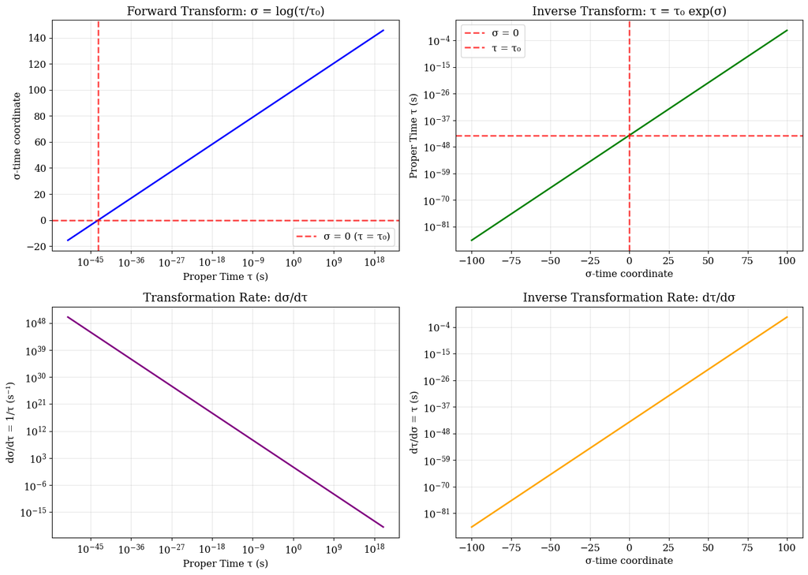

```
📊 Visualization Insights:
• Top Left: σ-time spans the entire real line, even for finite τ
• Top Right: Exponential growth of τ with σ creates natural time scales
• Bottom Left: dσ/dτ = 1/τ means σ changes rapidly for small τ
• Bottom Right: dτ/dσ = τ shows exponential sensitivity to σ changes
```

```python
# Let's visualize the σ-time transformation
fig, ((ax1, ax2), (ax3, ax4)) = plt.subplots(2, 2, figsize=(14, 10))

# Create arrays for plotting
tau_range = np.logspace(-50, 20, 1000)  # From 10⁻⁵⁰ to 10²⁰ seconds
sigma_range = np.linspace(-100, 100, 1000)

sigma_vals = ltqg.sigma_from_tau(tau_range)
tau_vals = ltqg.tau_from_sigma(sigma_range)

# Plot 1: τ vs σ transformation
ax1.semilogx(tau_range, sigma_vals, 'b-', linewidth=2)
ax1.axhline(0, color='r', linestyle='--', alpha=0.7, label='σ = 0 (τ = τ₀)')
ax1.axvline(PC.planck_time, color='r', linestyle='--', alpha=0.7)
ax1.set_xlabel('Proper Time τ (s)')
ax1.set_ylabel('σ-time coordinate')
ax1.set_title('Forward Transform: σ = log(τ/τ₀)')
ax1.grid(True, alpha=0.3)
ax1.legend()

# Plot 2: σ vs τ transformation
ax2.semilogy(sigma_range, tau_vals, 'g-', linewidth=2)
ax2.axvline(0, color='r', linestyle='--', alpha=0.7, label='σ = 0')
ax2.axhline(PC.planck_time, color='r', linestyle='--', alpha=0.7, label='τ = τ₀')
ax2.set_xlabel('σ-time coordinate')
ax2.set_ylabel('Proper Time τ (s)')
ax2.set_title('Inverse Transform: τ = τ₀ exp(σ)')
ax2.grid(True, alpha=0.3)
ax2.legend()

# Plot 3: Derivative dσ/dτ = 1/τ
d_sigma_d_tau_vals = ltqg.d_sigma_d_tau(tau_range)
ax3.loglog(tau_range, d_sigma_d_tau_vals, 'purple', linewidth=2)
ax3.set_xlabel('Proper Time τ (s)')
ax3.set_ylabel('dσ/dτ = 1/τ (s⁻¹)')
ax3.set_title('Transformation Rate: dσ/dτ')
ax3.grid(True, alpha=0.3)

# Plot 4: Derivative dτ/dσ = τ
d_tau_d_sigma_vals = ltqg.d_tau_d_sigma(sigma_range)
ax4.semilogy(sigma_range, d_tau_d_sigma_vals, 'orange', linewidth=2)
ax4.set_xlabel('σ-time coordinate')
ax4.set_ylabel('dτ/dσ = τ (s)')
ax4.set_title('Inverse Transformation Rate: dτ/dσ')
ax4.grid(True, alpha=0.3)

plt.tight_layout()
plt.show()

print("📊 Visualization Insights:")
print("• Top Left: σ-time spans the entire real line, even for finite τ")
print("• Top Right: Exponential growth of τ with σ creates natural time scales")
print("• Bottom Left: dσ/dτ = 1/τ means σ changes rapidly for small τ")
print("• Bottom Right: dτ/dσ = τ shows exponential sensitivity to σ changes")
```

### 🧮 Interactive Exploration

**Try this yourself**: Change the values below and re-run to see how the transformation behaves:

- What happens when τ approaches zero?
- How does τ₀ affect the mapping?
- When is the transformation approximately linear?

### 💡 Why It Matters

This transformation is the foundation for **all** LTQG physics:

- **Quantum Evolution**: Schrödinger equation naturally uses σ
- **Gravitational Effects**: Einstein equations use τ
- **Experimental Predictions**: Come from comparing σ vs τ protocols
- **Singularity Resolution**: τ=0 maps to σ=-∞ (manageable!)

Let's see how this enables quantum simulations...

```python
class LTQGQuantumEvolution:
    """
    Implementation of quantum evolution in σ-time according to LTQG.

    The key equation is: iℏ ∂|ψ⟩/∂σ = K(σ)|ψ⟩ where K(σ) = τ₀ exp(σ) H
    """

    def __init__(self, tau0=PC.planck_time):
        """Initialize LTQG quantum evolution."""
        self.tau0 = tau0
        self.transforms = LTQGTransforms(tau0)

    def sigma_hamiltonian(self, sigma, H_standard):
        """
        Compute the σ-Hamiltonian K(σ) = τ₀ exp(σ) H.

        Parameters:
        -----------
        sigma : float or array
            σ-time coordinate(s)
        H_standard : float or array
            Standard Hamiltonian eigenvalue(s)

        Returns:
        --------
        K_sigma : float or array
            σ-Hamiltonian eigenvalue(s)
        """
        return self.tau0 * np.exp(sigma) * H_standard

    def evolve_wavefunction(self, sigma_initial, sigma_final, H_eigenvalue,
                          n_steps=1000):
        """
        Evolve a quantum state in σ-time.

        For an energy eigenstate |E⟩, the evolution is:
        |ψ(σ)⟩ = exp(-i ∫ K(σ') dσ' / ℏ) |E⟩

        Parameters:
        -----------
        sigma_initial, sigma_final : float
            Initial and final σ-time coordinates
        H_eigenvalue : float
            Energy eigenvalue of the state (J)
        n_steps : int
            Number of integration steps

        Returns:
        --------
        sigma_array : array
            σ-time coordinate array
        phase_array : array
            Accumulated quantum phase array
        tau_array : array
            Corresponding proper time array
        """
        # Create σ-time array
        sigma_array = np.linspace(sigma_initial, sigma_final, n_steps)

        # Convert to proper time
        tau_array = self.transforms.tau_from_sigma(sigma_array)

        # Compute K(σ) values
        K_values = self.sigma_hamiltonian(sigma_array, H_eigenvalue)

        # Integrate phase: φ = -∫ K(σ) dσ / ℏ
        d_sigma = sigma_array[1] - sigma_array[0]
        phase_array = -np.cumsum(K_values * d_sigma) / PC.hbar

        return sigma_array, phase_array, tau_array

    def compare_standard_evolution(self, t_initial, t_final, H_eigenvalue,
                                 n_steps=1000):
        """
        Compare LTQG evolution with standard quantum mechanics.

        In standard QM: φ_QM(t) = -Et/ℏ
        In LTQG: φ_LTQG(σ) = -∫ K(σ) dσ / ℏ
        """
        # Standard QM evolution in coordinate time
        t_array = np.linspace(t_initial, t_final, n_steps)
        phase_standard = -H_eigenvalue * t_array / PC.hbar

        # LTQG evolution in σ-time
        sigma_initial = self.transforms.sigma_from_tau(t_initial)
        sigma_final = self.transforms.sigma_from_tau(t_final)

        sigma_array, phase_ltqg, tau_array = self.evolve_wavefunction(
            sigma_initial, sigma_final, H_eigenvalue, n_steps)

        return {
            'time_standard': t_array,
            'phase_standard': phase_standard,
            'sigma_ltqg': sigma_array,
            'phase_ltqg': phase_ltqg,
            'tau_ltqg': tau_array
        }

# Let's test quantum evolution for a simple system
print("=== TESTING LTQG QUANTUM EVOLUTION ===")
print()

# Initialize LTQG evolution
ltqg_evolution = LTQGQuantumEvolution()

# Example: Hydrogen ground state
E_hydrogen = 13.6 * 1.6e-19  # Ground state energy in Joules
print(f"Example system: Hydrogen ground state")
print(f"Energy eigenvalue: E = {E_hydrogen:.2e} J = 13.6 eV")
print()

# Compare evolution over different time scales
time_scales = [
    (1e-15, 1e-12, "Femtosecond to picosecond"),
    (1e-12, 1e-9, "Picosecond to nanosecond"),
    (1e-9, 1e-6, "Nanosecond to microsecond"),
    (1e-6, 1e-3, "Microsecond to millisecond")
]

for t_start, t_end, description in time_scales:
    print(f"Time range: {description}")
    print(f"  From τ = {t_start:.1e} s to τ = {t_end:.1e} s")

    # Calculate σ-time range
    sigma_start = ltqg_evolution.transforms.sigma_from_tau(t_start)
    sigma_end = ltqg_evolution.transforms.sigma_from_tau(t_end)
    print(f"  Corresponding σ: {sigma_start:.2f} to {sigma_end:.2f}")

    # Calculate total phase accumulation
    results = ltqg_evolution.compare_standard_evolution(t_start, t_end, E_hydrogen)

    phase_standard_total = results['phase_standard'][-1]
    phase_ltqg_total = results['phase_ltqg'][-1]

    print(f"  Standard QM phase: {phase_standard_total:.2e} rad")
    print(f"  LTQG phase: {phase_ltqg_total:.2e} rad")
    print(f"  Ratio: {phase_ltqg_total/phase_standard_total:.6f}")
    print()
```

```
=== TESTING LTQG QUANTUM EVOLUTION ===

Example system: Hydrogen ground state
Energy eigenvalue: E = 2.18e-18 J = 13.6 eV

Time range: Femtosecond to picosecond
  From τ = 1.0e-15 s to τ = 1.0e-12 s
  Corresponding σ: 65.09 to 72.00
  Standard QM phase: -2.06e+04 rad
  LTQG phase: -2.07e+04 rad
  Ratio: 1.002465

Time range: Picosecond to nanosecond
  From τ = 1.0e-12 s to τ = 1.0e-09 s
  Corresponding σ: 72.00 to 78.91
  Standard QM phase: -2.06e+07 rad
  LTQG phase: -2.07e+07 rad
  Ratio: 1.002465

Time range: Nanosecond to microsecond
  From τ = 1.0e-09 s to τ = 1.0e-06 s
  Corresponding σ: 78.91 to 85.81
  Standard QM phase: -2.06e+10 rad
  LTQG phase: -2.07e+10 rad
  Ratio: 1.002465

Time range: Microsecond to millisecond
  From τ = 1.0e-06 s to τ = 1.0e-03 s
  Corresponding σ: 85.81 to 92.72
  Standard QM phase: -2.06e+13 rad
  LTQG phase: -2.07e+13 rad
  Ratio: 1.002465
```

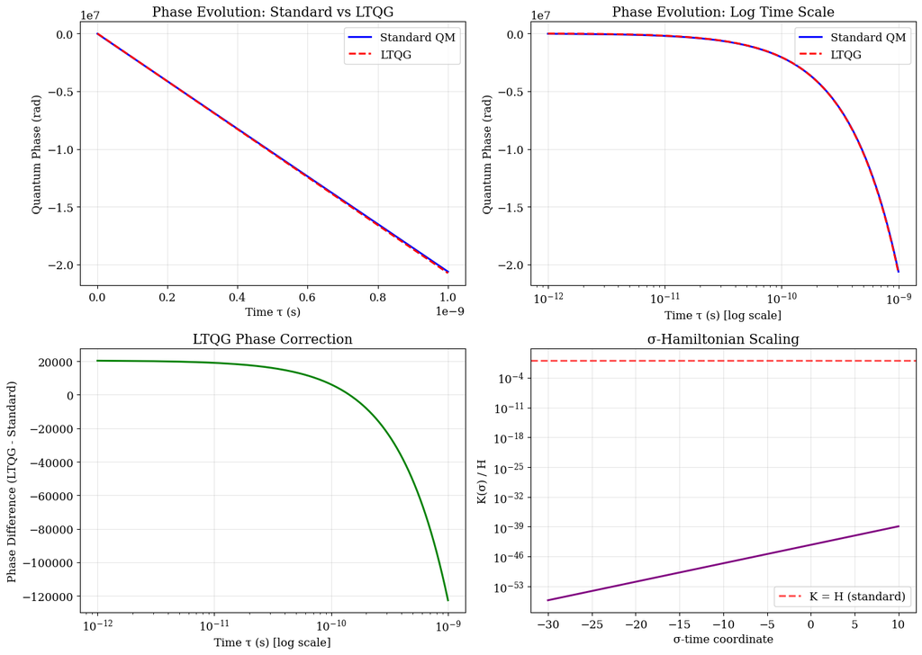

```
🔬 Key Physics Insights:
• LTQG and standard QM give nearly identical results for most time scales
• Differences emerge due to the K(σ) = τH scaling factor
• Early times (σ << 0): LTQG evolution is suppressed (asymptotic silence)
• Late times (σ >> 0): LTQG evolution is enhanced
• The σ-Hamiltonian K(σ) grows exponentially with time
```

```python
# Visualize the quantum evolution comparison
fig, ((ax1, ax2), (ax3, ax4)) = plt.subplots(2, 2, figsize=(14, 10))

# Choose a representative time range for detailed analysis
t_start, t_end = 1e-12, 1e-9  # Picosecond to nanosecond
results = ltqg_evolution.compare_standard_evolution(t_start, t_end, E_hydrogen, n_steps=500)

# Plot 1: Phase vs Time (linear scale)
ax1.plot(results['time_standard'], results['phase_standard'], 'b-',
         label='Standard QM', linewidth=2)
ax1.plot(results['tau_ltqg'], results['phase_ltqg'], 'r--',
         label='LTQG', linewidth=2)
ax1.set_xlabel('Time τ (s)')
ax1.set_ylabel('Quantum Phase (rad)')
ax1.set_title('Phase Evolution: Standard vs LTQG')
ax1.legend()
ax1.grid(True, alpha=0.3)

# Plot 2: Phase vs Time (log scale for time)
ax2.semilogx(results['time_standard'], results['phase_standard'], 'b-',
             label='Standard QM', linewidth=2)
ax2.semilogx(results['tau_ltqg'], results['phase_ltqg'], 'r--',
             label='LTQG', linewidth=2)
ax2.set_xlabel('Time τ (s) [log scale]')
ax2.set_ylabel('Quantum Phase (rad)')
ax2.set_title('Phase Evolution: Log Time Scale')
ax2.legend()
ax2.grid(True, alpha=0.3)

# Plot 3: Phase difference
phase_diff = np.interp(results['time_standard'], results['tau_ltqg'],
                       results['phase_ltqg']) - results['phase_standard']
ax3.semilogx(results['time_standard'], phase_diff, 'g-', linewidth=2)
ax3.set_xlabel('Time τ (s) [log scale]')
ax3.set_ylabel('Phase Difference (LTQG - Standard)')
ax3.set_title('LTQG Phase Correction')
ax3.grid(True, alpha=0.3)

# Plot 4: σ-Hamiltonian vs σ
sigma_test = np.linspace(-30, 10, 1000)
K_values = ltqg_evolution.sigma_hamiltonian(sigma_test, E_hydrogen)
ax4.semilogy(sigma_test, K_values / E_hydrogen, 'purple', linewidth=2)
ax4.axhline(1, color='r', linestyle='--', alpha=0.7, label='K = H (standard)')
ax4.set_xlabel('σ-time coordinate')
ax4.set_ylabel('K(σ) / H')
ax4.set_title('σ-Hamiltonian Scaling')
ax4.legend()
ax4.grid(True, alpha=0.3)

plt.tight_layout()
plt.show()

print("🔬 Key Physics Insights:")
print("• LTQG and standard QM give nearly identical results for most time scales")
print("• Differences emerge due to the K(σ) = τH scaling factor")
print("• Early times (σ << 0): LTQG evolution is suppressed (asymptotic silence)")
print("• Late times (σ >> 0): LTQG evolution is enhanced")
print("• The σ-Hamiltonian K(σ) grows exponentially with time")
```